# Estimation_Practice_Lab_Yerim_Oh

## Estimating species abundance

Today you are going to use some of the new tools we have learned to explore how we might estimate the number of species in an ecosystem based on a random sampling of animals. As with the airplanes, you will know what the truth is which will enable you to assess how well an estimation works.

```python
# Run this cell to set up the notebook, but please don't change it.

# These lines import the Numpy and Datascience modules.
import numpy as np
from datascience import *

# These lines do some fancy plotting magic.
import matplotlib
import matplotlib.pyplot as plt
plt.style.use('fivethirtyeight')
%matplotlib inline
import warnings
warnings.simplefilter('ignore', FutureWarning)
```

```python
## First, a little for-loop practice.
## I want a for-loop that takes each of the items in an array of vegetables and prints out, "I like ___"

veggie_array = make_array("broccoli", "spinach","potatoes")

for x in veggie_array:
    print("I like",x)
```

```
I like broccoli
I like spinach
I like potatoes
```

```python
## Now, write a function using a for-loop that takes a string as an input and prints the number of times each vowel
## appears in the string.

## Hint: To determine the number of times a letter appears in a string, you can compare the length of the string
## in its original form to its length with the given letter removed.

def vowel_counter(string):
    # string of vowels
    vowels = "aeiou"
    # casefold has been used to ignore cases
    string = string.casefold()

    # form a dictionary with key as a vowel and the value as 0
    count = {}.fromkeys(vowels, 0)

    # count the vowels
    for character in string:
        if character in count:
            count[character] += 1
    return count

vowel_counter("apple")
```

```
{'a': 1, 'e': 1, 'i': 0, 'o': 0, 'u': 0}
```

## Estimating species in ecosystem 1

The function below enables you to take a random sample of mammals living in an ecosystem in Australia. The function takes as an input the sample size

```python
def mammal_sample(n):
    '''Returns a random sample of mammals from a section of the Australian outback'''
    ecosystem = Table.read_table("/srv/data/DS_113_S23/Labs/Estimation_Practice_Lab/mammals.csv").column(0)
    return np.random.choice(ecosystem,n)

mammal_sample(1)
```

```
array(['Bilby'],
      dtype='<U22')
```

```python
## Use the function to take a sample of 30 animals.  Give it a name for further analysis.
sample = mammal_sample(30)
sample
```

```
array(['Koala', 'Bandicoot', 'Brush Tailed Possum', 'Wallaby', 'Kanagaroo',
       'Wallaby', 'Wallaroo', 'Wombat ', 'Wombat ', 'Koala', 'Wallaby',
       'Wallaby', 'Brush Tailed Possum', 'Spotted-Tail Quoll', 'Koala',
       'Wombat ', 'Wombat ', 'Grey Headed Flying Fox', 'Wombat ',
       'Wombat ', 'Wallaroo', 'Brush Tailed Possum', 'Rufous Bettong',
       'Bandicoot', 'Dingo', 'Spotted-Tail Quoll', 'Rufous Bettong',
       'Wallaroo', 'Dingo', 'Wallaroo'],
      dtype='<U22')
```

```python
## Write a line of code that will determine for you the number of different species in your sample.
Table().with_column("species",sample).group("species").num_rows
```

```
11
```

Suppose you wanted to estimate the total number of different mammal species in the ecosystem. Suppose we took the number of species in our sample as an estimate. How good an estimate is this? That is what we will explore below.

```python
## Use a for-loop to take 1000 different samples of size 30.
## Consider each an estimate of the total number of mammal species.
## You should produce an array of estimates that I would like you to report as a table.

estimateArray = make_array()

for i in np.arange(1000):
    sampled_mammal = mammal_sample(30)
    estimateArray = np.append(estimateArray, Table().with_column("species",sampled_mammal).group("species").num_rows)

estimates = Table().with_column("estimated species", estimateArray)
estimates
```

| estimated species |
| --- |
| 11 |
| 10 |
| 10 |
| 10 |
| 11 |
| 12 |
| 11 |
| 12 |
| 11 |
| 12 |

... (990 rows omitted)

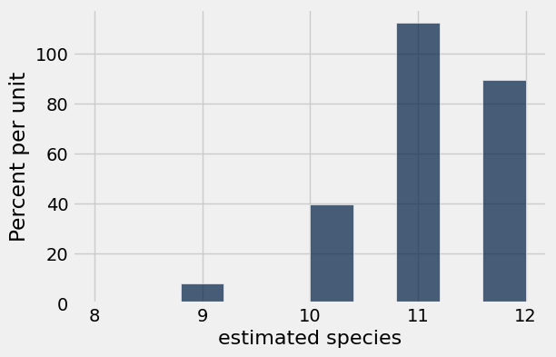

```python
## Create an appropriate histogram of your estimates.
estimates.hist(bins=10)
```

```python
## Run this code to look at the actual species in the ecosystem.
species = Table.read_table("/srv/data/DS_113_S23/Labs/Estimation_Practice_Lab/mammals.csv").column(0)
Table().with_columns(
    "Number", np.arange(1,len(species)+1),
    "Species", species
).show()
```

| Number | Species |
| --- | --- |
| 1 | Dingo |
| 2 | Kanagaroo |
| 3 | Wallaby |
| 4 | Bandicoot |
| 5 | Bilby |
| 6 | Brush Tailed Possum |
| 7 | Grey Headed Flying Fox |
| 8 | Koala |
| 9 | Rufous Bettong |
| 10 | Spotted-Tail Quoll |
| 11 | Wombat |
| 12 | Wallaroo |

Comment on the accuracy of this estimation method as well as any other characteristics that help you determine how useful it is.

Since the maximum number we have found from the estimate is 12, we can know that there will be 12 species in the ecosystem.

Repeat your work above, but now with a sample size of 100. Place your new code below and then comment on how this changed the accuracy of your method.

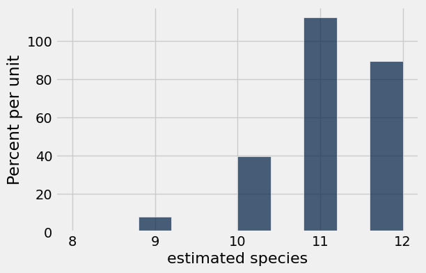

```python
estimateArray100 = make_array()

for i in np.arange(1000):
    sampled_mammal_100 = mammal_sample(100)
    estimateArray100 = np.append(estimateArray100,
                                 Table().with_column("species",sampled_mammal_100).group("species").num_rows)

estimates100 = Table().with_column("estimated species", estimateArray)

# histogram of the table
estimates100.hist(bins=10)
```

## Estimating species in ecosystem 2

The function below enables you to take a random sample of reptiles and amphibians living in an ecosystem in Montana, USA. The function takes as an input the sample size. There is one significant difference for this ecosystem. In our Australian ecosystem, each species had the same chance of being found. This is not representative of reality. In this ecosystem, some species are more abundant than others.

```python
def herp_sample(n):
    '''Returns a random sample of reptiles and amphibians from Montana'''
    ecosystem = Table.read_table("/srv/data/DS_113_S23/Labs/Estimation_Practice_Lab/Reptiles.csv").column(0)
    x = make_array(200, 180, 150, 120, 100, 80, 60, 30, 10, 5, 3, 2, 2, 1, 1, 1, 1, 1)
    return np.random.choice(ecosystem,n, p = x/sum(x))

herp_sample(1)
```

```
array(['Great Plains Toad'],
      dtype='<U21')
```

Please repeat the work you did for Ecosystem 1 except this time start with a sample size of 100 and increase to a sample size of 1000 for your second run through. When you are ready to observe the true number of species in this ecosystem, please run the code below.

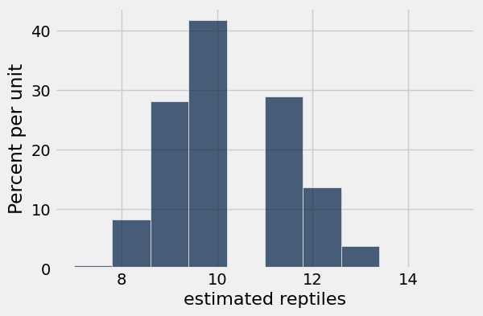

```python
estimateReptiles100 = make_array()

for i in np.arange(1000):
    sampled_Reptiles_100 = herp_sample(100)
    estimateReptiles100 = np.append(estimateReptiles100,
                                 Table().with_column("species",sampled_Reptiles_100).group("species").num_rows)

reptiles100 = Table().with_column("estimated reptiles", estimateReptiles100)

# histogram of the table
reptiles100.hist(bins=10)
```

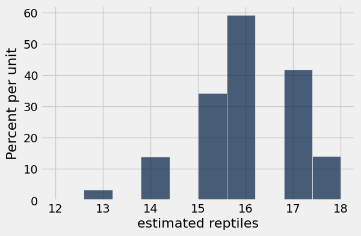

```python
estimateReptiles1000 = make_array()

for i in np.arange(1000):
    sampled_Reptiles_1000 = herp_sample(1000)
    estimateReptiles1000 = np.append(estimateReptiles1000,
                                 Table().with_column("species",sampled_Reptiles_1000).group("species").num_rows)

reptiles1000 = Table().with_column("estimated reptiles", estimateReptiles1000)

# histogram of the table
reptiles1000.hist(bins=10)
```

```python
## Run this code to look at the actual species in the ecosystem.
species = Table.read_table("/srv/data/DS_113_S23/Labs/Estimation_Practice_Lab/Reptiles.csv").column(0)
Table().with_columns(
    "Number", np.arange(1,len(species)+1),
    "Species", species
).show()
```

| Number | Species |
| --- | --- |
| 1 | Tiger Salamander |
| 2 | Pacific Tree Frog |
| 3 | Boreal Chorus Frog |
| 4 | Western Toad |
| 5 | Woodhouse Toad |
| 6 | Great Plains Toad |
| 7 | American Bullfrog |
| 8 | Columbia Spotted Frog |
| 9 | Sagebrush Lizard |
| 10 | Gopher Snake |
| 11 | Eastern Racer |
| 12 | Western Skink |
| 13 | Milksnake |
| 14 | Snapping Turtle |
| 15 | Smooth Greensnake |
| 16 | Painted Turtle |
| 17 | Rubber Boa |
| 18 | Spiny Softshell |

Please comment on the effectiveness of your method in this second ecosystem. How could you modify your method to increase your accuracy?

Compared to the estimation of the sample size of 100, the estimation with the sample size of 1000 showed more number of species. Since there are more species than the first ecosystem, the bigger sample size would help us to figure out the number of species more accurately.

## Estimating some probabilities

Using your method with 1000 samples, please estimate the following:

1. The probability of your method producing the right answer.
2. The probability of your method being wrong by more than 3 species.

```python
probability_right = (len(reptiles1000.where("estimated reptiles", are.equal_to(18)).column(0)))/1000
probability_right
```

```
0.085
```

```python
probability_wrong_3 = (len(reptiles1000.where("estimated reptiles", are.below_or_equal_to(15)).column(0)))/1000
probability_wrong_3
```

```
0.31
```

If you have time, please ponder a more sophisticated approach to estimating the number of species. In particular, what might you look at in a sample to decide whether or not you are not likely to find any new species if you keep searching?